# Analysis of White Wines

Kevin Turner

January 24, 2019

The data set contains 4,898 white wines with 11 attributes on quantifying the chemical properties of each wine and 1 attribute providing a quality score as determined by at least 3 expert wine tasters. Quality was rated on a scale of 0 to 10.

Let’s have a look at the attributes available within this dataset.

```
##  [1] "fixed.acidity"        "volatile.acidity"     "citric.acid"
##  [4] "residual.sugar"       "chlorides"            "free.sulfur.dioxide"
##  [7] "total.sulfur.dioxide" "density"              "pH"
## [10] "sulphates"            "alcohol"              "quality"
```

#### Description of attributes:

1. fixed acidity (tartaric acid - g / dm^3): most acids involved with wine are fixed or nonvolatile (do not evaporate readily)
2. volatile acidity (acetic acid - g / dm^3): the amount of acetic acid in wine, which at too high of levels can lead to an unpleasant, vinegar taste
3. citric acid (g / dm^3): found in small quantities, citric acid can add ‘freshness’ and flavor to wines
4. residual sugar (g / dm^3): the amount of sugar remaining after fermentation stops, it’s rare to find wines with less than 1 gram/liter and wines with greater than 45 grams/liter are considered sweet
5. chlorides (sodium chloride - g / dm^3): the amount of salt in the wine
6. free sulfur dioxide (mg / dm^3): the free form of SO2 exists in equilibrium between molecular SO2 (as a dissolved gas) and bisulfite ion; it prevents microbial growth and the oxidation of wine
7. total sulfur dioxide (mg / dm^3): amount of free and bound forms of S02; in low concentrations, SO2 is mostly undetectable in wine, but at free SO2 concentrations over 50 ppm, SO2 becomes evident in the nose and taste of wine
8. density (g / cm^3): the density of wine is close to that of water depending on the percent alcohol and sugar content
9. pH: describes how acidic or basic a wine is on a scale from 0 (very acidic) to 14 (very basic); most wines are between 3-4 on the pH scale
10. sulphates (potassium sulphate - g / dm3): a wine additive which can contribute to sulfur dioxide gas (S02) levels, wich acts as an antimicrobial and antioxidant
11. alcohol (% by volume): the percent alcohol content of the wine
12. quality (score between 0 and 10) - Output variable (based on sensory data)

# Univariate Plots

Now that we know more about the attributes involved with our dataset, let’s have a look at how these attributes are structered.

```
## 'data.frame':    4898 obs. of  12 variables:
##  $ fixed.acidity       : num  7 6.3 8.1 7.2 7.2 8.1 6.2 7 6.3 8.1 ...
##  $ volatile.acidity    : num  0.27 0.3 0.28 0.23 0.23 0.28 0.32 0.27 0.3 0.22 ...
##  $ citric.acid         : num  0.36 0.34 0.4 0.32 0.32 0.4 0.16 0.36 0.34 0.43 ...
##  $ residual.sugar      : num  20.7 1.6 6.9 8.5 8.5 6.9 7 20.7 1.6 1.5 ...
##  $ chlorides           : num  0.045 0.049 0.05 0.058 0.058 0.05 0.045 0.045 0.049 0.044 ...
##  $ free.sulfur.dioxide : num  45 14 30 47 47 30 30 45 14 28 ...
##  $ total.sulfur.dioxide: num  170 132 97 186 186 97 136 170 132 129 ...
##  $ density             : num  1.001 0.994 0.995 0.996 0.996 ...
##  $ pH                  : num  3 3.3 3.26 3.19 3.19 3.26 3.18 3 3.3 3.22 ...
##  $ sulphates           : num  0.45 0.49 0.44 0.4 0.4 0.44 0.47 0.45 0.49 0.45 ...
##  $ alcohol             : num  8.8 9.5 10.1 9.9 9.9 10.1 9.6 8.8 9.5 11 ...
##  $ quality             : int  6 6 6 6 6 6 6 6 6 6 ...
```

Most of the variables are of the numeric type, which makes sense as the data represents qauntative measurements. The last variable, Quality, is of the type integer since values were recorded as whole numbers on a scale of 0 to 10.

Next, let’s take a statistical look at the values.

```
##  fixed.acidity    volatile.acidity  citric.acid     residual.sugar
##  Min.   : 3.800   Min.   :0.0800   Min.   :0.0000   Min.   : 0.600
##  1st Qu.: 6.300   1st Qu.:0.2100   1st Qu.:0.2700   1st Qu.: 1.700
##  Median : 6.800   Median :0.2600   Median :0.3200   Median : 5.200
##  Mean   : 6.855   Mean   :0.2782   Mean   :0.3342   Mean   : 6.391
##  3rd Qu.: 7.300   3rd Qu.:0.3200   3rd Qu.:0.3900   3rd Qu.: 9.900
##  Max.   :14.200   Max.   :1.1000   Max.   :1.6600   Max.   :65.800
##    chlorides       free.sulfur.dioxide total.sulfur.dioxide
##  Min.   :0.00900   Min.   :  2.00      Min.   :  9.0
##  1st Qu.:0.03600   1st Qu.: 23.00      1st Qu.:108.0
##  Median :0.04300   Median : 34.00      Median :134.0
##  Mean   :0.04577   Mean   : 35.31      Mean   :138.4
##  3rd Qu.:0.05000   3rd Qu.: 46.00      3rd Qu.:167.0
##  Max.   :0.34600   Max.   :289.00      Max.   :440.0
##     density             pH          sulphates         alcohol
##  Min.   :0.9871   Min.   :2.720   Min.   :0.2200   Min.   : 8.00
##  1st Qu.:0.9917   1st Qu.:3.090   1st Qu.:0.4100   1st Qu.: 9.50
##  Median :0.9937   Median :3.180   Median :0.4700   Median :10.40
##  Mean   :0.9940   Mean   :3.188   Mean   :0.4898   Mean   :10.51
##  3rd Qu.:0.9961   3rd Qu.:3.280   3rd Qu.:0.5500   3rd Qu.:11.40
##  Max.   :1.0390   Max.   :3.820   Max.   :1.0800   Max.   :14.20
##     quality
##  Min.   :3.000
##  1st Qu.:5.000
##  Median :6.000
##  Mean   :5.878
##  3rd Qu.:6.000
##  Max.   :9.000
```

After reviewing the statistical information there are a few interesting observations. Some of the attributes have large gaps between thier 3rd Quartile and Max values. We’ll look a bit more at those in a minute.

First, lets take a quick view of how the wines rated by quality.

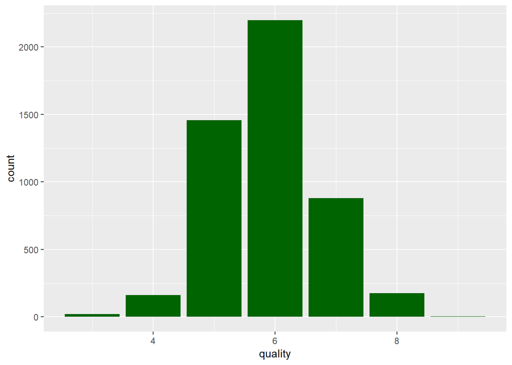

The quality of the wines we are anlyzing look to follow a nice bell curve with most wines falling in the middle of the scale and a one or two on each end.

Now lets see a quick visual overview of the rest of our data points.

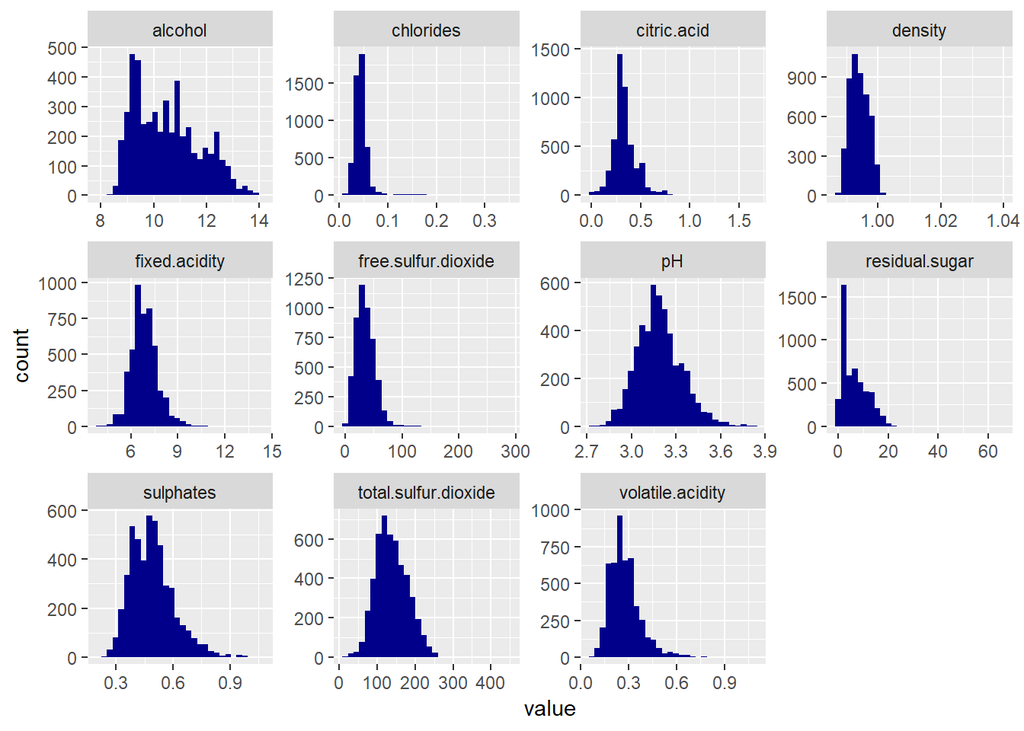

From the histograms above we can see that some of our data is close to normal distribution while other data is right skewed. There are no attributes that are left skewed in the dataset. We can also deduce that there are outliers in several attributes based on the bin widths and what appears to be large empty space to the right of the bars.

Lets have a closer look at a **chlorides** and **free.sulfur.dioxide**, two of the attributes that appear to have extreme outliers.

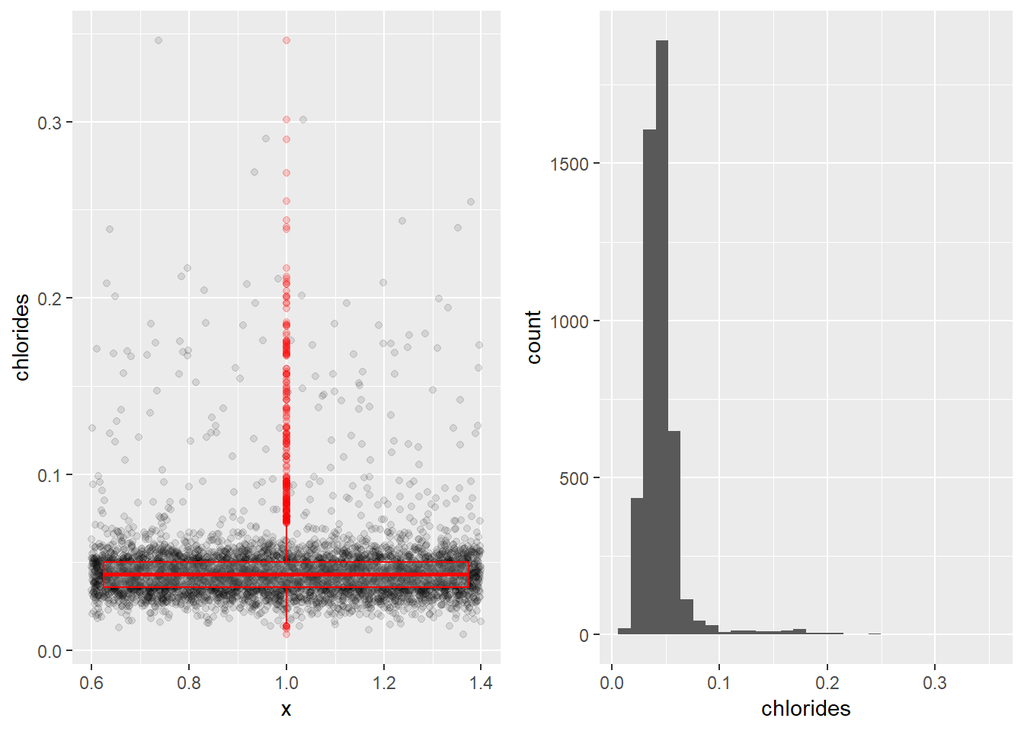

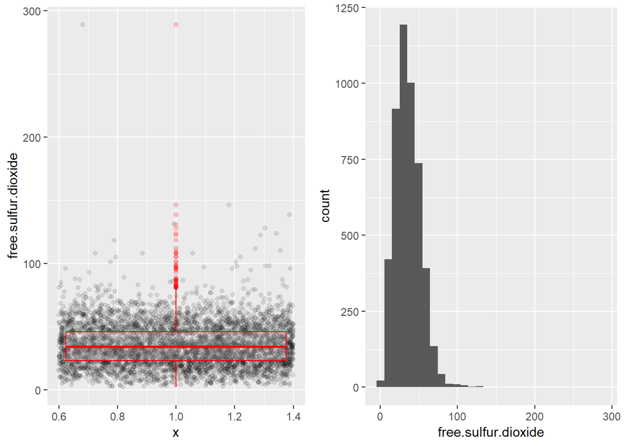

So our dateset contains quite a few outliers. These outliers could affect the outcome or quality of our analysis. So we will create a new dataframe that excludes all the rows of data that contains outiers in any of the attributes.

This new dataframe contains 3,973 observations. 925 rows that contained outliers were removed.

```
## 'data.frame':    3973 obs. of  12 variables:
##  $ fixed.acidity       : num  7 6.3 8.1 7.2 7.2 8.1 6.2 7 6.3 8.1 ...
##  $ volatile.acidity    : num  0.27 0.3 0.28 0.23 0.23 0.28 0.32 0.27 0.3 0.22 ...
##  $ citric.acid         : num  0.36 0.34 0.4 0.32 0.32 0.4 0.16 0.36 0.34 0.43 ...
##  $ residual.sugar      : num  20.7 1.6 6.9 8.5 8.5 6.9 7 20.7 1.6 1.5 ...
##  $ chlorides           : num  0.045 0.049 0.05 0.058 0.058 0.05 0.045 0.045 0.049 0.044 ...
##  $ free.sulfur.dioxide : num  45 14 30 47 47 30 30 45 14 28 ...
##  $ total.sulfur.dioxide: num  170 132 97 186 186 97 136 170 132 129 ...
##  $ density             : num  1.001 0.994 0.995 0.996 0.996 ...
##  $ pH                  : num  3 3.3 3.26 3.19 3.19 3.26 3.18 3 3.3 3.22 ...
##  $ sulphates           : num  0.45 0.49 0.44 0.4 0.4 0.44 0.47 0.45 0.49 0.45 ...
##  $ alcohol             : num  8.8 9.5 10.1 9.9 9.9 10.1 9.6 8.8 9.5 11 ...
##  $ quality             : int  6 6 6 6 6 6 6 6 6 6 ...
```

```
##  fixed.acidity   volatile.acidity  citric.acid     residual.sugar
##  Min.   :4.800   Min.   :0.0800   Min.   :0.1100   Min.   : 0.60
##  1st Qu.:6.300   1st Qu.:0.2100   1st Qu.:0.2700   1st Qu.: 1.80
##  Median :6.800   Median :0.2600   Median :0.3100   Median : 5.20
##  Mean   :6.814   Mean   :0.2638   Mean   :0.3228   Mean   : 6.35
##  3rd Qu.:7.300   3rd Qu.:0.3100   3rd Qu.:0.3700   3rd Qu.: 9.60
##  Max.   :8.800   Max.   :0.4850   Max.   :0.5400   Max.   :20.80
##    chlorides       free.sulfur.dioxide total.sulfur.dioxide
##  Min.   :0.01500   Min.   : 2.00       Min.   : 19.0
##  1st Qu.:0.03500   1st Qu.:24.00       1st Qu.:107.0
##  Median :0.04200   Median :34.00       Median :132.0
##  Mean   :0.04224   Mean   :34.71       Mean   :136.8
##  3rd Qu.:0.04900   3rd Qu.:45.00       3rd Qu.:166.0
##  Max.   :0.07100   Max.   :79.00       Max.   :253.0
##     density             pH          sulphates         alcohol
##  Min.   :0.9871   Min.   :2.820   Min.   :0.2200   Min.   : 8.40
##  1st Qu.:0.9916   1st Qu.:3.090   1st Qu.:0.4100   1st Qu.: 9.50
##  Median :0.9935   Median :3.180   Median :0.4700   Median :10.50
##  Mean   :0.9938   Mean   :3.189   Mean   :0.4812   Mean   :10.59
##  3rd Qu.:0.9959   3rd Qu.:3.280   3rd Qu.:0.5400   3rd Qu.:11.40
##  Max.   :1.0020   Max.   :3.570   Max.   :0.7600   Max.   :14.20
##     quality
##  Min.   :3.000
##  1st Qu.:5.000
##  Median :6.000
##  Mean   :5.953
##  3rd Qu.:6.000
##  Max.   :9.000
```

Lets have another look at **chlorides** and **free.sulfur.dioxide** after the outliers have been removed.

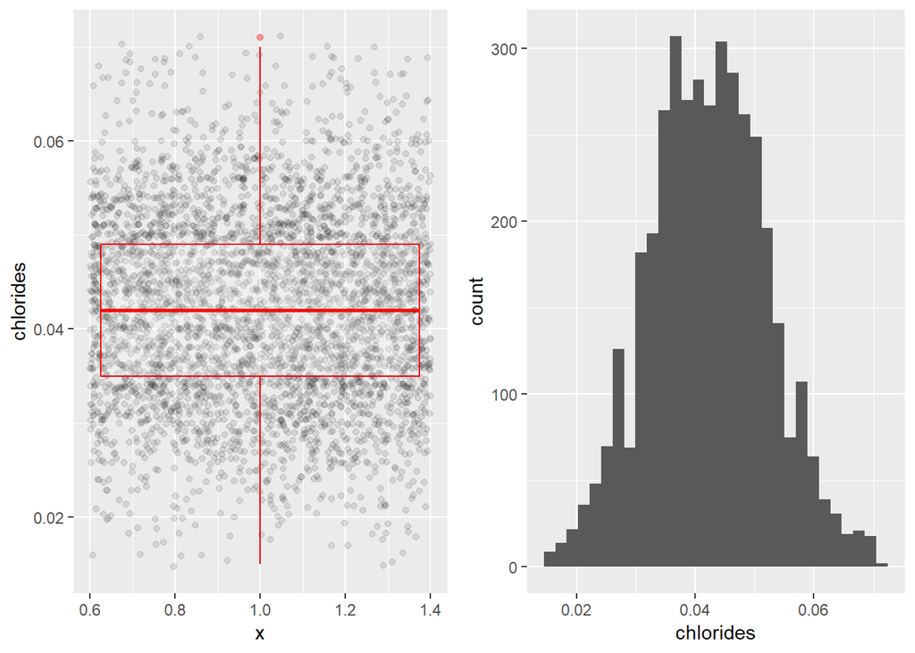

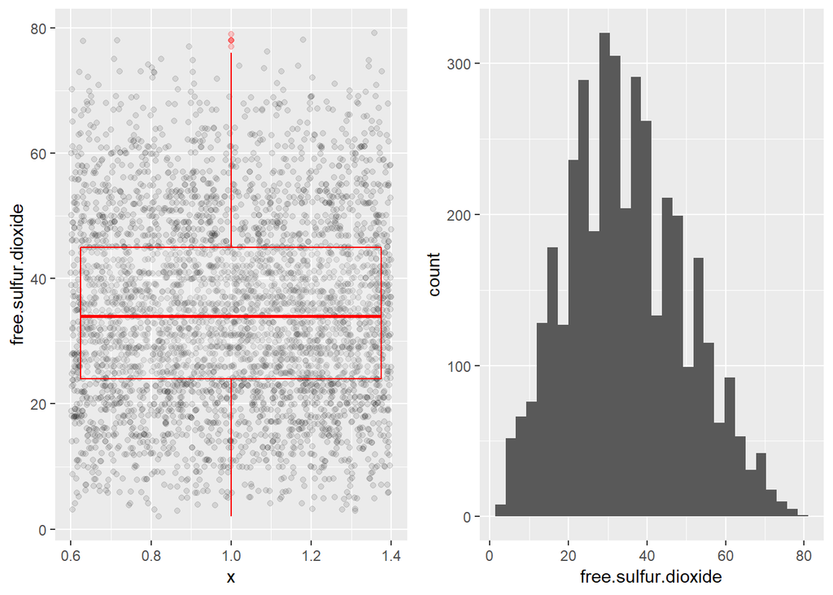

We can see that the data is much cleaner and easier to visualize now. For the rest of this anlysis we will be using the data that excludes the outliers.

# Univariate Analysis

The main feature of interest in this dataset would be the Quality score. Throughout this analysis we will investigate how the other variables contribute, positive or negative, to that quality score.

In order to organize the data in a way that was easier to display as an overview, the tidyr library was used to create a new dataframe. Utilizing this library, value:key pairs were created for each variable and value. This process is defined as taking “wide”" data, many columns and fewer rows, and making it “long”, many rows and fewer columns. The resulting dataframe’s structure contains 53,878 observations and 3 variables.

Most distributions with in this dataset can be described as right skewed, or close to a normal.

# Bivariate Plots

Let’s see if we can make any determinations as to whether any of these attributes have an affect on the **quality** of the wines.

We’ll start by looking for any correlations between each of the attributes.

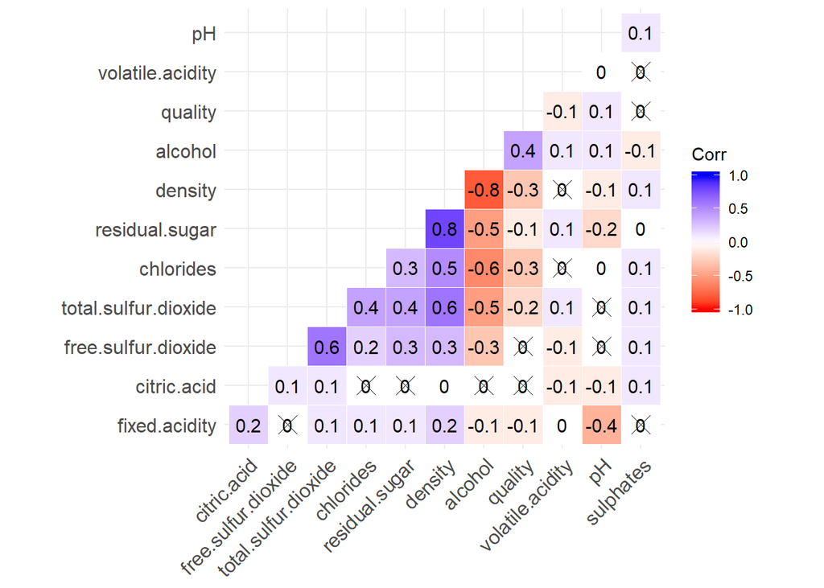

A correlation coefficient of > 4.0 is consindered a relatively strong relationship. Between 2.0 and 4.0 is considered moderate and anything less than 2.0 is weak.

This is pretty interesting. It appears that the strongest correlations are between **density** and both **alcohol** and **residual.sugar**. There also looks to be some moderate correlations between our main attribute of interest, **quality**, and the attributes **alcohol**, **density**, **chlorides**, and **total.sulfur.dioxide**.

Lets explore these relationships further.

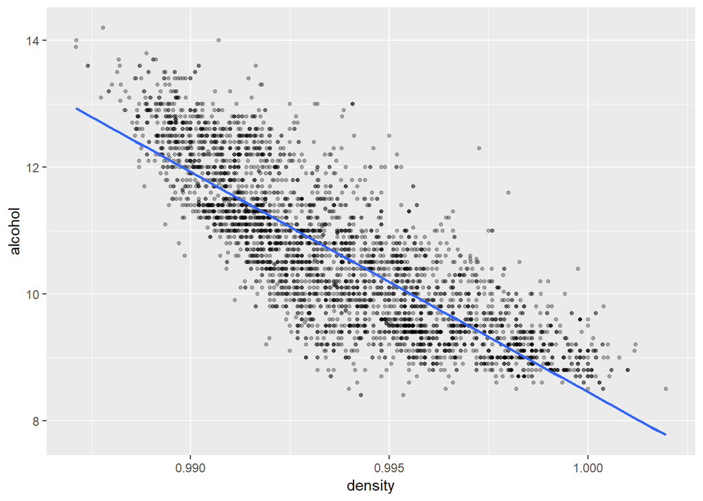

The relationship between **alcohol** and **denisty** is a negative relationship. This suggest that the higher the **alcohol** content of the wine, the less **dense** the wine will be.

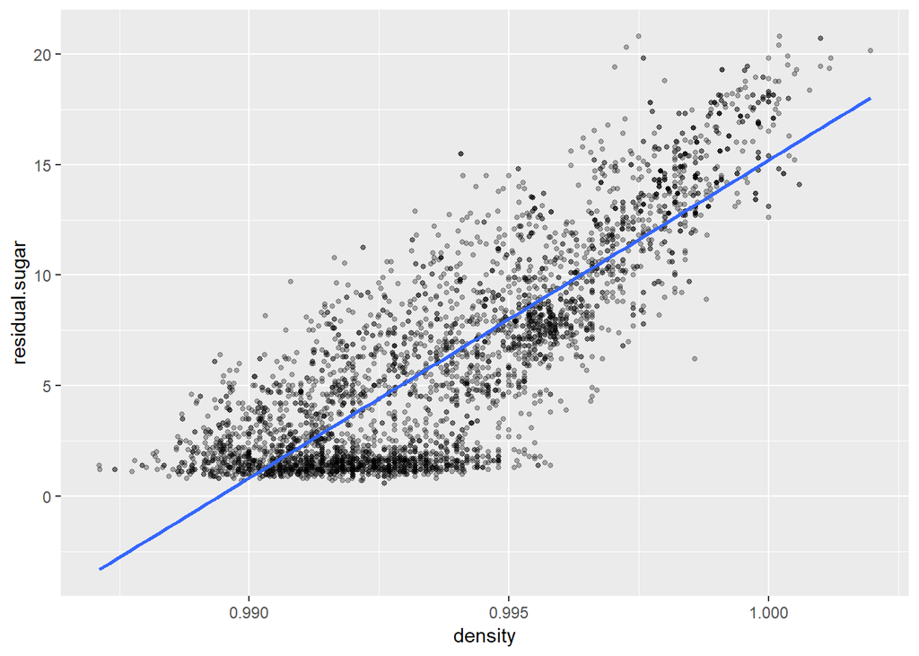

Conversely, the relationship between **residual.sugar** and **density** is a postive. This makes sense since it would seem logical that the more **sugar** that exists in the wine the more **dense** it would become.

So what does the relationship between **residual.sugar** and **alcohol** look like?

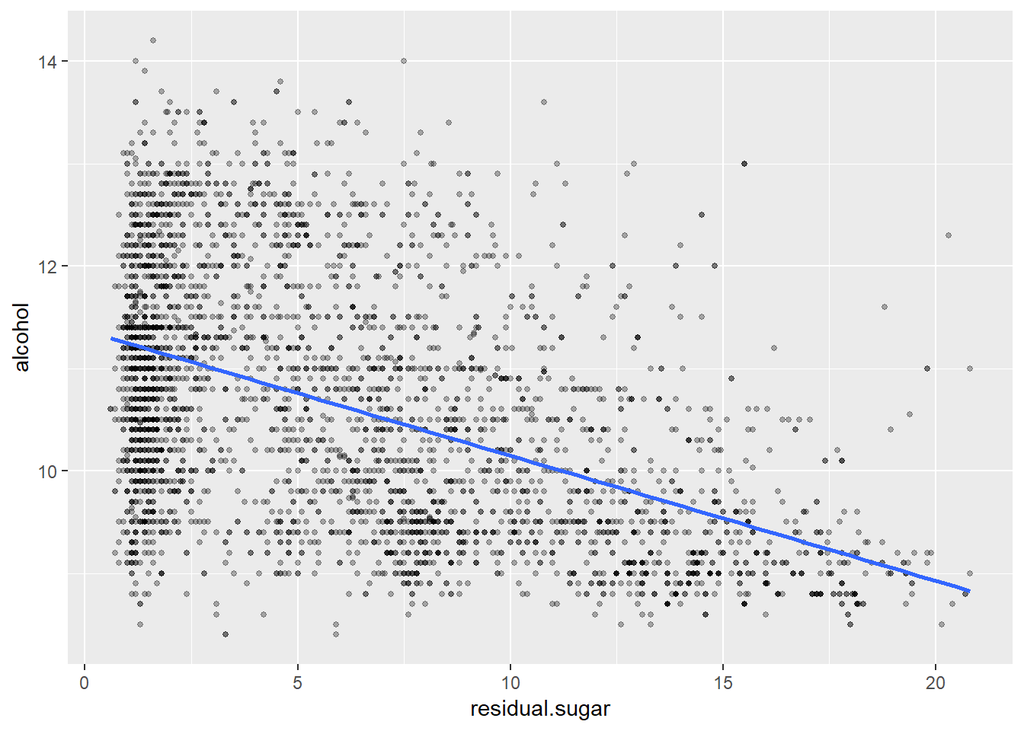

The negative relationship we see above coincides with the previous relationships we explored. A lower **residual.sugar** value tends to result in a higher **alcohol** content.

How about **quality**? Let’s look at some of the moderate relationships between **quality** and the other attributes.

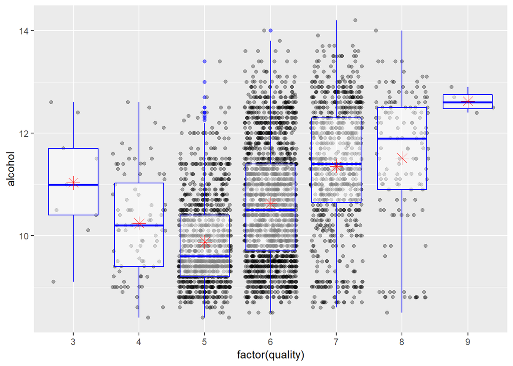

We’ve already determined that no strong relationships exist between the rated **quality** of the wine and any other attributes. At best there are a few moderate relationships. When comparing **quality** to **alcohol**, we see that amongst the wines rated between 5 and 8 there exists **alcohol** values from the whole range in the dataset. In fact the highest rated wines contain only higher alcohol percentages. This observation may just be a result of a relatively small dataset.

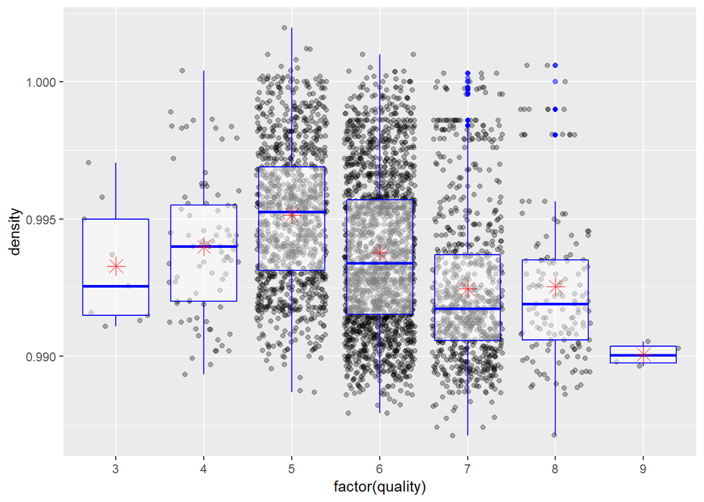

As with **alcohol**, **denstiy** values are spread accross each of the **quality** levels. The highest quality level only contains lower **density**. This coincides with the relationship between **desnity** and **alcohol** that we looked at earlier.

Lets have have a look at the last two attributes with a moderate relationship, **chlorides** and **total.sulfur.dioxide**. I suspect we will see the same trend though.

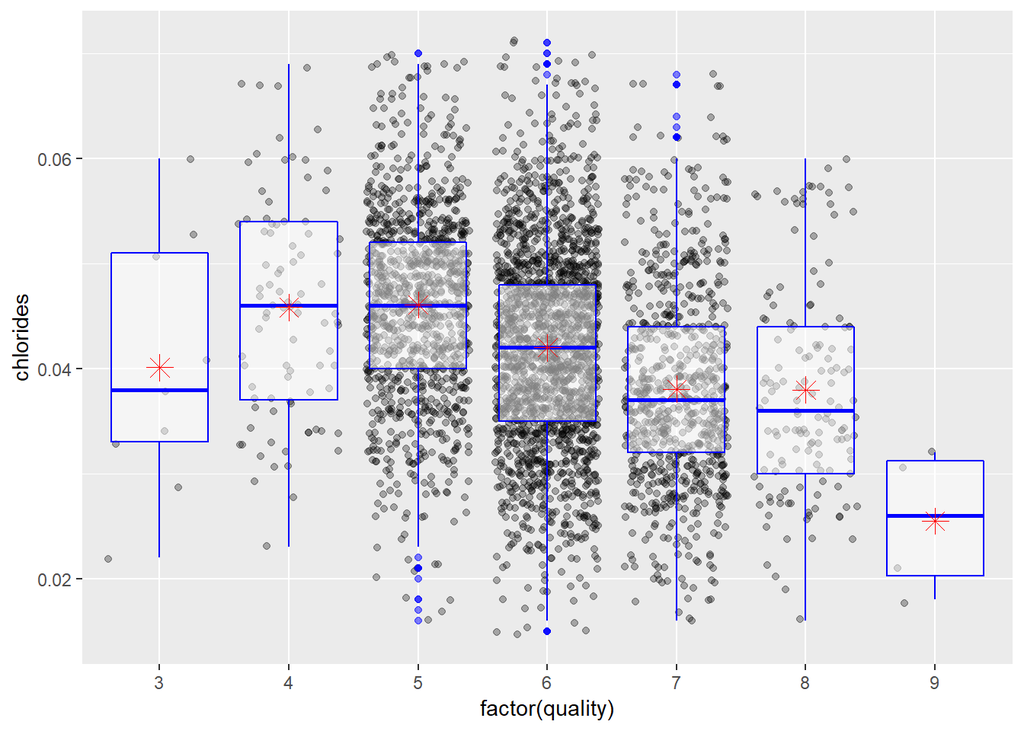

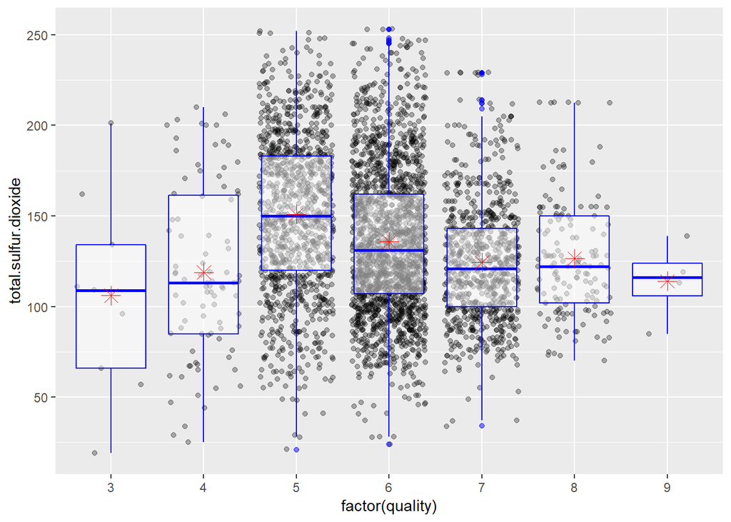

# Bivariate Analysis

We explored the relationship between seraval attributes through this bivariate analysis.

Begining with the srongest relationship between attributes **alcohol**/ **density** and **residual.sugar**/ **density** , then looking at our **quality** attribute and it’s moderate relationships.

Through this analysis I had hoped we would identify correlations between attributes and it’s related **quality** score, however given the data it’s not possible to derive how each attribute could be manipulated to affect the quality of wine.

# Multivariate Plots Section

Let’s take a look at the scatter plots we created earlier and overlay **quality** values on them.

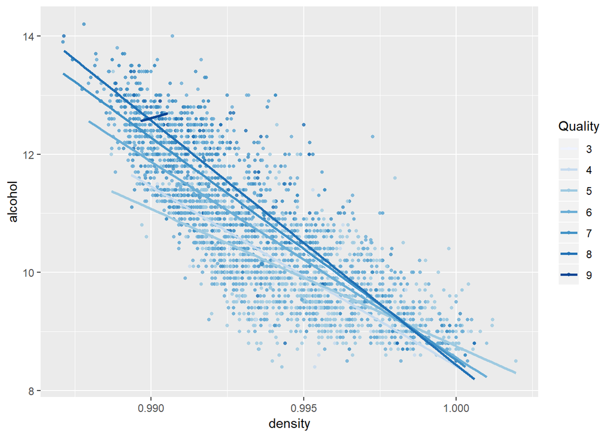

As before, we see the negative relationship between **alcohol** and **density**, but now it is much clearer that each **quality** value covers the whole range of of values in the other attributes, but the highest **quality** of 9 only spans over a small set of values in the other attributes.

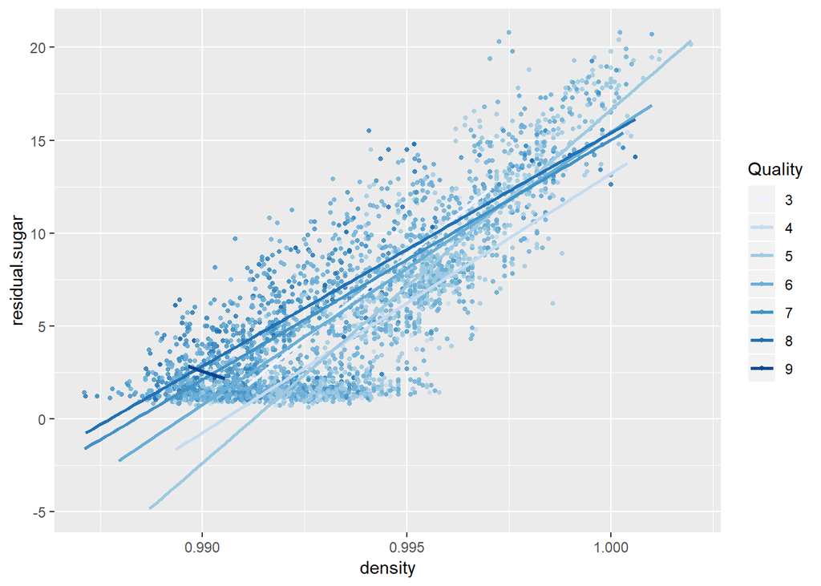

An interesting observation in this graph and the previous one is that the **quality** value of 9 has an oposite trend as the others. That’s to say that if the the trend is postive for **quality** values 3 through 8, then 9 is negative.

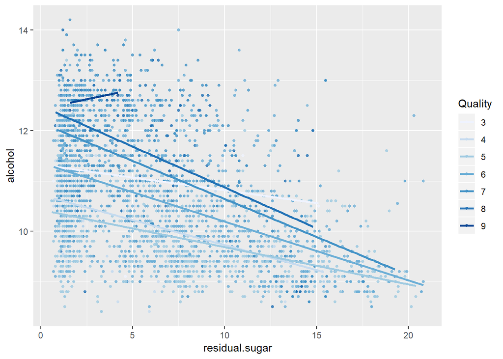

Again we can see the same trend where only the highest **quality** value of 9 is limited to a small range in the other attributes values and the **quality** value of 9 follows and oppisite trend than the rest of the **quality** values.

# Multivariate Analysis

The most intersting finding from the multivariate analysis would have relate to the **quality** attribute. When **quality** is analyzed along with other attributes each level of quality follows the same trend , postive or negative, with the eception of the highest **quality** rating of 9. The highest **quality** rating of 9 consistently trends opposite of the other ratings.

# Final Plots and Summary

We’ve spent a bit of time exploring the dataset. We learned a lot and came to the conclusion that even though **Quality Score** appeared to be a good starting focus as a main attribute, there was not a lot of evidence that any one or combination of atributes directly contributed to it.

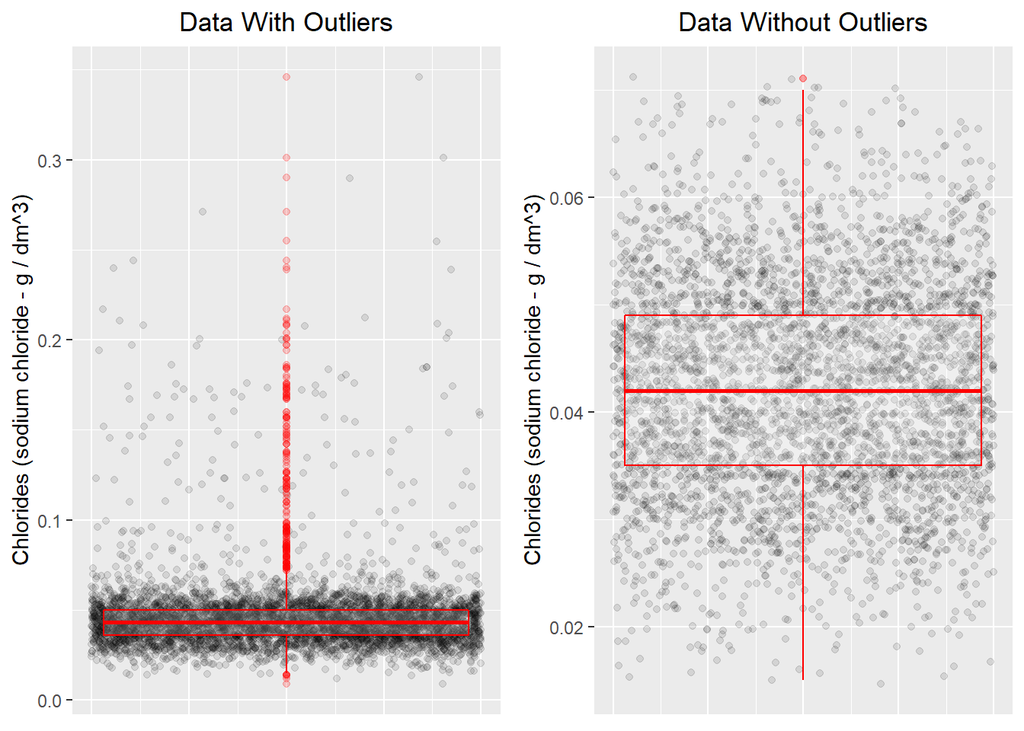

When we began our analysis we found that our dataset contained a lot of outliers. In order to mitigate the effect that had on our analysis, a new subset of the data was created to remove those outliers.

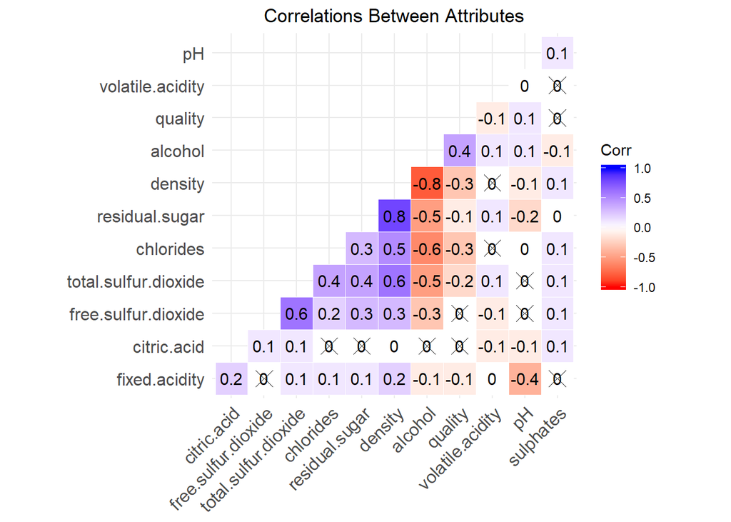

After ensuring all outliers were removed from the dataset, we had a look at the correlation between each of the attributes to determine is there were any relationships beyond **quality** that were of intrest to look at.

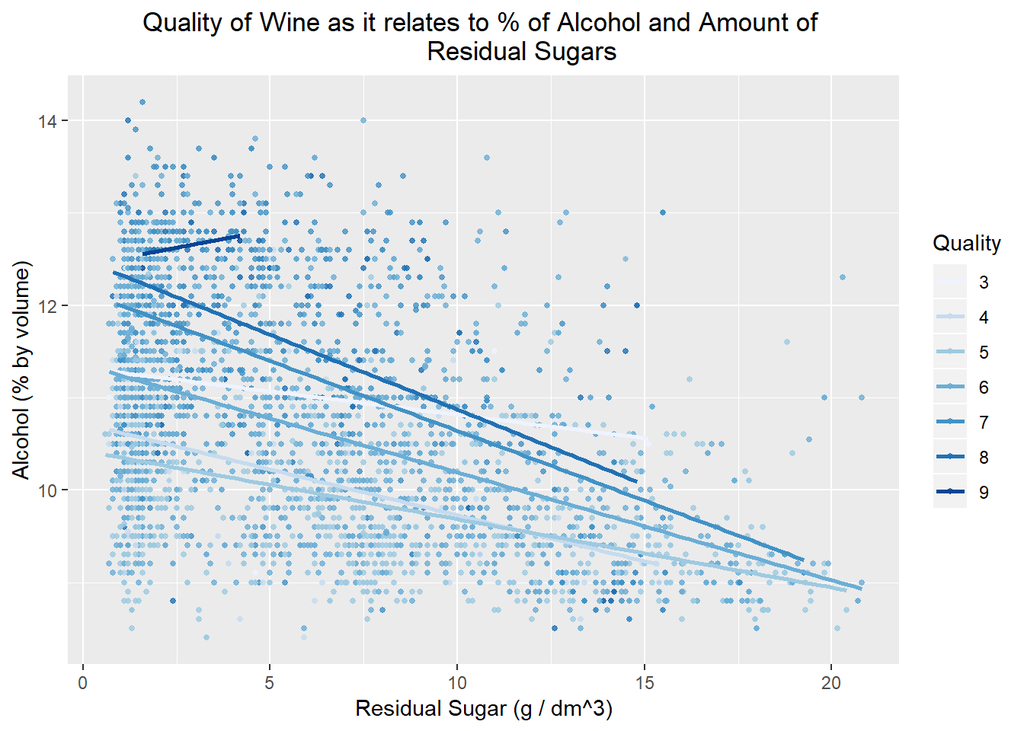

Finally we explored some of the attribute through bivarite and multivariate analysis.

# Reflection

Working with this dataset and the R language was a fun experience. Understanding what graphs and charts would represent the data appropriatly was a challenge at times.

It may be possible to create a predicitive model of creating **quality** wine from the data avaialbe. It would certainly be more benificial if the dataset contained much more data to analyze.